# Gapminder Visualisierung

### group_by und summarise

Zuletzt kommt es öfter vor, dass wir gruppierte Operationen durchführen wollen (d.h. für subsets unseres datafarmes). Hier kommt vor allem `group_by` und `summarise` öfter zum Zug; group_by kann aber auch in Verbindung mit anderen Befehlen (z.B. `mutate`) problemlos verwendet werden.

*Wichtig ist bei der Verwendung von `group_by` nur, die Gruppierung im Anschluss mit `ungroup` wieder aufzuheben.*

Wir könnten beispielsweise die durchschnittliche Lebenserwartung aller Länder über die Jahre hinweg abbilden:

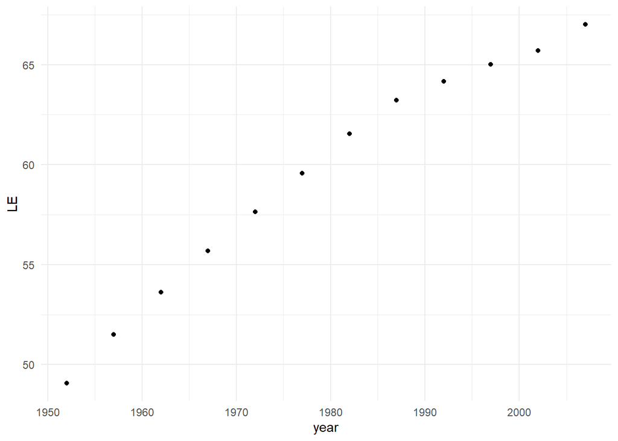

```r
# install.packages('ggthemes')
library(ggthemes) # mehr vorprogramierte plot designs!
Warning: package 'ggthemes' was built under R version 4.0.5

df %>%
  # alle folgenden Operationen geschehen innerhalb der jeweiligen Jahreteilsegmente / untergruppen
  group_by(year) %>%
  summarise(
    LE=mean(lifeExp)
  ) %>%
  # Sehr simple Visualisierung hierfür
  ggplot(aes(x=year,y=LE)) +
  theme_minimal() +# in ggplot gibt es mehrere vorprogramierte designs, siehe weiter unten
  geom_point()
```

Ggplot hat bereits ein paar vorprogramierte designs, das package `ggthemes` hat aber noch viel mehr! Sobald das packet installiert und geladen ist, sind diese dir über normale `them_*` Befehle wie `theme_minimal()` zugägnlich!

**Aufgabe:** Installiere und lade das Paket, und finde das theme mit dem ich die folgende Visualisierung gemacht habe. (Tipp ich habe auch den `shape` der Punkte verändert!)

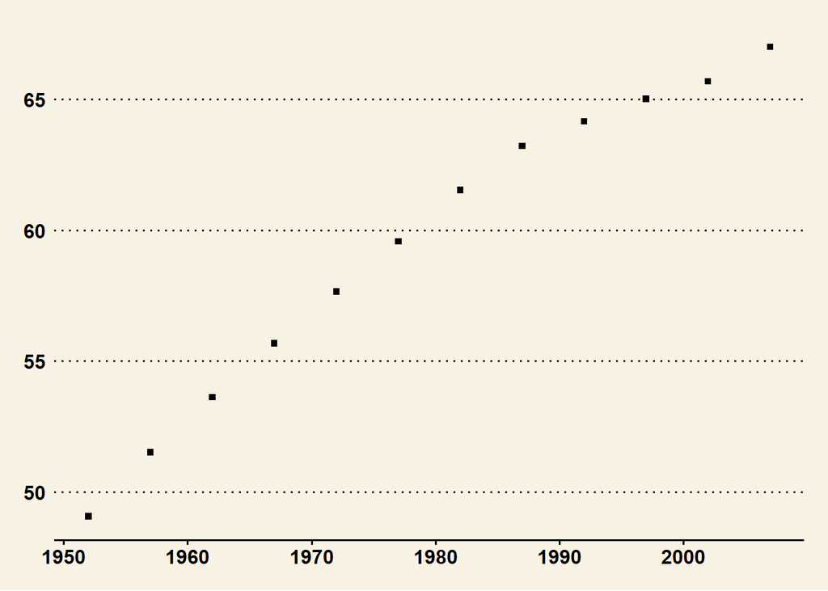